# Risk Factor Analysis

## Outcome Variable

**Outcome Variable:** wasted

## Predictor Variables

**Intervention Variable:** parity

**Adjustment Set:**

unadjusted

## Stratifying Variables

The analysis was stratified on these variable(s):

- agecat
- studyid
- country

## Data Summary

| agecat | studyid | country | parity | wasted | n_cell | n |
| --- | --- | --- | --- | --- | --- | --- |
| Birth | COHORTS | GUATEMALA | 1 | 0 | 66 | 756 |
| Birth | COHORTS | GUATEMALA | 1 | 1 | 28 | 756 |
| Birth | COHORTS | GUATEMALA | 2 | 0 | 87 | 756 |
| Birth | COHORTS | GUATEMALA | 2 | 1 | 31 | 756 |
| Birth | COHORTS | GUATEMALA | 3+ | 0 | 411 | 756 |
| Birth | COHORTS | GUATEMALA | 3+ | 1 | 133 | 756 |
| Birth | COHORTS | INDIA | 1 | 0 | 505 | 3855 |
| Birth | COHORTS | INDIA | 1 | 1 | 136 | 3855 |
| Birth | COHORTS | INDIA | 2 | 0 | 823 | 3855 |
| Birth | COHORTS | INDIA | 2 | 1 | 159 | 3855 |
| Birth | COHORTS | INDIA | 3+ | 0 | 1876 | 3855 |
| Birth | COHORTS | INDIA | 3+ | 1 | 356 | 3855 |
| Birth | COHORTS | PHILIPPINES | 1 | 0 | 497 | 2899 |
| Birth | COHORTS | PHILIPPINES | 1 | 1 | 143 | 2899 |
| Birth | COHORTS | PHILIPPINES | 2 | 0 | 552 | 2899 |
| Birth | COHORTS | PHILIPPINES | 2 | 1 | 105 | 2899 |
| Birth | COHORTS | PHILIPPINES | 3+ | 0 | 1399 | 2899 |
| Birth | COHORTS | PHILIPPINES | 3+ | 1 | 203 | 2899 |
| Birth | GMS-Nepal | NEPAL | 1 | 0 | 137 | 641 |
| Birth | GMS-Nepal | NEPAL | 1 | 1 | 48 | 641 |
| Birth | GMS-Nepal | NEPAL | 2 | 0 | 132 | 641 |
| Birth | GMS-Nepal | NEPAL | 2 | 1 | 37 | 641 |
| Birth | GMS-Nepal | NEPAL | 3+ | 0 | 240 | 641 |
| Birth | GMS-Nepal | NEPAL | 3+ | 1 | 47 | 641 |
| Birth | JiVitA-3 | BANGLADESH | 1 | 0 | 4770 | 18014 |
| Birth | JiVitA-3 | BANGLADESH | 1 | 1 | 750 | 18014 |
| Birth | JiVitA-3 | BANGLADESH | 2 | 0 | 5688 | 18014 |
| Birth | JiVitA-3 | BANGLADESH | 2 | 1 | 615 | 18014 |
| Birth | JiVitA-3 | BANGLADESH | 3+ | 0 | 5583 | 18014 |
| Birth | JiVitA-3 | BANGLADESH | 3+ | 1 | 608 | 18014 |

[output cut: 144 more lines]

The following strata were considered:

- agecat: 24 months, studyid: COHORTS, country: GUATEMALA
- agecat: 24 months, studyid: COHORTS, country: INDIA
- agecat: 24 months, studyid: COHORTS, country: PHILIPPINES
- agecat: 24 months, studyid: GMS-Nepal, country: NEPAL
- agecat: 24 months, studyid: JiVitA-3, country: BANGLADESH
- agecat: 24 months, studyid: Keneba, country: GAMBIA
- agecat: 24 months, studyid: PROVIDE, country: BANGLADESH
- agecat: 24 months, studyid: TanzaniaChild2, country: TANZANIA, UNITED REPUBLIC OF
- agecat: 24 months, studyid: ZVITAMBO, country: ZIMBABWE
- agecat: 6 months, studyid: COHORTS, country: GUATEMALA
- agecat: 6 months, studyid: COHORTS, country: INDIA
- agecat: 6 months, studyid: COHORTS, country: PHILIPPINES
- agecat: 6 months, studyid: GMS-Nepal, country: NEPAL
- agecat: 6 months, studyid: JiVitA-3, country: BANGLADESH
- agecat: 6 months, studyid: Keneba, country: GAMBIA
- agecat: 6 months, studyid: PROVIDE, country: BANGLADESH
- agecat: 6 months, studyid: SAS-CompFeed, country: INDIA
- agecat: 6 months, studyid: SAS-FoodSuppl, country: INDIA
- agecat: 6 months, studyid: TanzaniaChild2, country: TANZANIA, UNITED REPUBLIC OF
- agecat: 6 months, studyid: ZVITAMBO, country: ZIMBABWE
- agecat: Birth, studyid: COHORTS, country: GUATEMALA
- agecat: Birth, studyid: COHORTS, country: INDIA
- agecat: Birth, studyid: COHORTS, country: PHILIPPINES
- agecat: Birth, studyid: GMS-Nepal, country: NEPAL
- agecat: Birth, studyid: JiVitA-3, country: BANGLADESH
- agecat: Birth, studyid: Keneba, country: GAMBIA
- agecat: Birth, studyid: PROVIDE, country: BANGLADESH
- agecat: Birth, studyid: SAS-CompFeed, country: INDIA
- agecat: Birth, studyid: ZVITAMBO, country: ZIMBABWE

### Dropped Strata

Some strata were dropped due to rare outcomes:

- agecat: 6 months, studyid: COHORTS, country: GUATEMALA
- agecat: 6 months, studyid: SAS-FoodSuppl, country: INDIA
- agecat: 24 months, studyid: TanzaniaChild2, country: TANZANIA, UNITED REPUBLIC OF

## Methods Detail

We’re interested in the causal parameters $E[Y_a]$ for all values of $a \in \mathcal{A}$. These parameters represent the mean outcome if, possibly contrary to fact, we intervened to set all units to have $A=a$. Under the randomization and positivity assumptions, these are identified by the statistical parameters $\psi_a=E_W[E_{Y|A,W}(Y|A=a,W)]$. In addition, we’re interested in the mean of $Y$, $E[Y]$ under no intervention (the observed mean). We will estimate these parameters by using SuperLearner to fit the relevant likelihood factors – $E_{Y|A,W}(Y|A=a,W)$ and $p(A=a|W)$, and then updating our likelihood fit using a joint TMLE.

For unadjusted analyses ($W=\{\}$), initial likelihoods were estimated using Lrnr_glm to estimate the simple $E(Y|A)$ and Lrnr_mean to estimate $p(A)$. For adjusted analyses, a small library containing Lrnr_glmnet, Lrnr_xgboost, and Lrnr_mean was used.

Having estimated these parameters, we will then use the delta method to estimate relative risks and attributable risks relative to a prespecified baseline level of $A$.

# Results Detail

## Results Plots

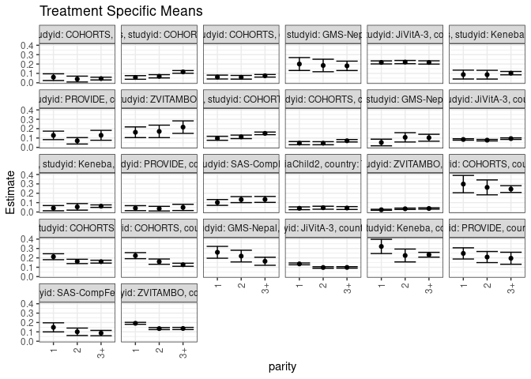

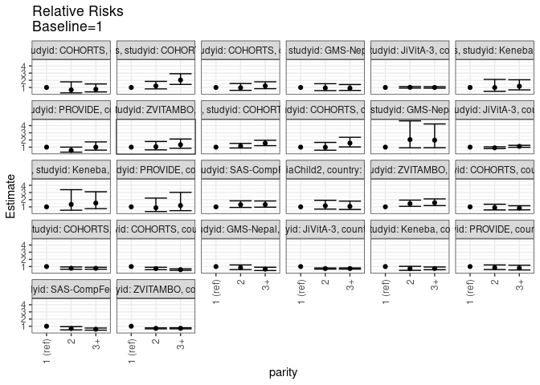

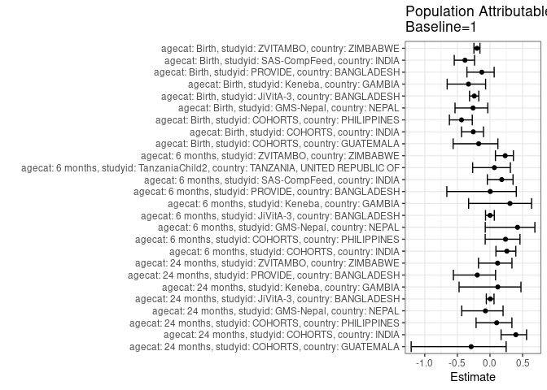

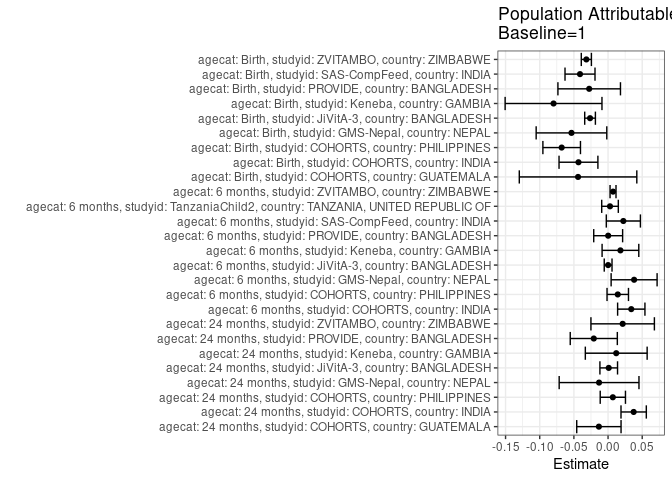

## Results Table

### Parameter: TSM

| agecat | studyid | country | intervention_level | baseline_level | estimate | ci_lower | ci_upper |
| --- | --- | --- | --- | --- | --- | --- | --- |
| Birth | COHORTS | GUATEMALA | 1 | NA | 0.2978723 | 0.2053611 | 0.3903836 |
| Birth | COHORTS | GUATEMALA | 2 | NA | 0.2627119 | 0.1832511 | 0.3421727 |
| Birth | COHORTS | GUATEMALA | 3+ | NA | 0.2444853 | 0.2083456 | 0.2806249 |
| Birth | COHORTS | INDIA | 1 | NA | 0.2121685 | 0.1805142 | 0.2438228 |
| Birth | COHORTS | INDIA | 2 | NA | 0.1619145 | 0.1388716 | 0.1849573 |
| Birth | COHORTS | INDIA | 3+ | NA | 0.1594982 | 0.1443066 | 0.1746898 |
| Birth | COHORTS | PHILIPPINES | 1 | NA | 0.2234375 | 0.1911600 | 0.2557150 |
| Birth | COHORTS | PHILIPPINES | 2 | NA | 0.1598174 | 0.1317928 | 0.1878419 |
| Birth | COHORTS | PHILIPPINES | 3+ | NA | 0.1267166 | 0.1104242 | 0.1430090 |
| Birth | GMS-Nepal | NEPAL | 1 | NA | 0.2594595 | 0.1962459 | 0.3226730 |
| Birth | GMS-Nepal | NEPAL | 2 | NA | 0.2189349 | 0.1565406 | 0.2813292 |
| Birth | GMS-Nepal | NEPAL | 3+ | NA | 0.1637631 | 0.1209162 | 0.2066099 |
| Birth | JiVitA-3 | BANGLADESH | 1 | NA | 0.1358696 | 0.1259658 | 0.1457733 |
| Birth | JiVitA-3 | BANGLADESH | 2 | NA | 0.0975726 | 0.0893771 | 0.1057681 |
| Birth | JiVitA-3 | BANGLADESH | 3+ | NA | 0.0982071 | 0.0902743 | 0.1061398 |
| Birth | Keneba | GAMBIA | 1 | NA | 0.3219178 | 0.2461041 | 0.3977315 |
| Birth | Keneba | GAMBIA | 2 | NA | 0.2253521 | 0.1566058 | 0.2940984 |
| Birth | Keneba | GAMBIA | 3+ | NA | 0.2333333 | 0.2077411 | 0.2589255 |
| Birth | PROVIDE | BANGLADESH | 1 | NA | 0.2475248 | 0.1879535 | 0.3070960 |
| Birth | PROVIDE | BANGLADESH | 2 | NA | 0.2087912 | 0.1496864 | 0.2678960 |
| Birth | PROVIDE | BANGLADESH | 3+ | NA | 0.1959459 | 0.1319376 | 0.2599543 |
| Birth | SAS-CompFeed | INDIA | 1 | NA | 0.1480263 | 0.0996843 | 0.1963683 |
| Birth | SAS-CompFeed | INDIA | 2 | NA | 0.1007752 | 0.0609820 | 0.1405684 |
| Birth | SAS-CompFeed | INDIA | 3+ | NA | 0.0868762 | 0.0582808 | 0.1154715 |
| Birth | ZVITAMBO | ZIMBABWE | 1 | NA | 0.1913325 | 0.1809937 | 0.2016712 |
| Birth | ZVITAMBO | ZIMBABWE | 2 | NA | 0.1349820 | 0.1242325 | 0.1457315 |
| Birth | ZVITAMBO | ZIMBABWE | 3+ | NA | 0.1361935 | 0.1247858 | 0.1476012 |
| 6 months | COHORTS | INDIA | 1 | NA | 0.0971660 | 0.0758380 | 0.1184940 |
| 6 months | COHORTS | INDIA | 2 | NA | 0.1125343 | 0.0937970 | 0.1312716 |
| 6 months | COHORTS | INDIA | 3+ | NA | 0.1497348 | 0.1356073 | 0.1638623 |
| 6 months | COHORTS | PHILIPPINES | 1 | NA | 0.0452962 | 0.0282810 | 0.0623114 |
| 6 months | COHORTS | PHILIPPINES | 2 | NA | 0.0444811 | 0.0280774 | 0.0608847 |
| 6 months | COHORTS | PHILIPPINES | 3+ | NA | 0.0708197 | 0.0579425 | 0.0836968 |
| 6 months | GMS-Nepal | NEPAL | 1 | NA | 0.0522876 | 0.0169835 | 0.0875917 |
| 6 months | GMS-Nepal | NEPAL | 2 | NA | 0.1073826 | 0.0576272 | 0.1571379 |
| 6 months | GMS-Nepal | NEPAL | 3+ | NA | 0.1030534 | 0.0662068 | 0.1399000 |
| 6 months | JiVitA-3 | BANGLADESH | 1 | NA | 0.0845577 | 0.0769209 | 0.0921945 |
| 6 months | JiVitA-3 | BANGLADESH | 2 | NA | 0.0772208 | 0.0692022 | 0.0852393 |
| 6 months | JiVitA-3 | BANGLADESH | 3+ | NA | 0.0938098 | 0.0854717 | 0.1021479 |
| 6 months | Keneba | GAMBIA | 1 | NA | 0.0410256 | 0.0131775 | 0.0688738 |
| 6 months | Keneba | GAMBIA | 2 | NA | 0.0548780 | 0.0200120 | 0.0897441 |
| 6 months | Keneba | GAMBIA | 3+ | NA | 0.0625000 | 0.0491515 | 0.0758485 |
| 6 months | PROVIDE | BANGLADESH | 1 | NA | 0.0412844 | 0.0148531 | 0.0677157 |
| 6 months | PROVIDE | BANGLADESH | 2 | NA | 0.0360360 | 0.0114985 | 0.0605736 |
| 6 months | PROVIDE | BANGLADESH | 3+ | NA | 0.0490798 | 0.0158874 | 0.0822721 |
| 6 months | SAS-CompFeed | INDIA | 1 | NA | 0.1020408 | 0.0710963 | 0.1329853 |
| 6 months | SAS-CompFeed | INDIA | 2 | NA | 0.1324503 | 0.1003673 | 0.1645334 |
| 6 months | SAS-CompFeed | INDIA | 3+ | NA | 0.1343750 | 0.1025712 | 0.1661788 |
| 6 months | TanzaniaChild2 | TANZANIA, UNITED REPUBLIC OF | 1 | NA | 0.0397644 | 0.0250630 | 0.0544657 |
| 6 months | TanzaniaChild2 | TANZANIA, UNITED REPUBLIC OF | 2 | NA | 0.0456621 | 0.0296958 | 0.0616284 |
| 6 months | TanzaniaChild2 | TANZANIA, UNITED REPUBLIC OF | 3+ | NA | 0.0425532 | 0.0271267 | 0.0579797 |
| 6 months | ZVITAMBO | ZIMBABWE | 1 | NA | 0.0238797 | 0.0187415 | 0.0290179 |
| 6 months | ZVITAMBO | ZIMBABWE | 2 | NA | 0.0344028 | 0.0273790 | 0.0414266 |
| 6 months | ZVITAMBO | ZIMBABWE | 3+ | NA | 0.0376238 | 0.0302013 | 0.0450462 |
| 24 months | COHORTS | GUATEMALA | 1 | NA | 0.0598802 | 0.0238784 | 0.0958821 |
| 24 months | COHORTS | GUATEMALA | 2 | NA | 0.0397351 | 0.0085646 | 0.0709056 |
| 24 months | COHORTS | GUATEMALA | 3+ | NA | 0.0448549 | 0.0301129 | 0.0595968 |
| 24 months | COHORTS | INDIA | 1 | NA | 0.0570410 | 0.0378467 | 0.0762353 |
| 24 months | COHORTS | INDIA | 2 | NA | 0.0692951 | 0.0520880 | 0.0865022 |
| 24 months | COHORTS | INDIA | 3+ | NA | 0.1160532 | 0.1018570 | 0.1302493 |
| 24 months | COHORTS | PHILIPPINES | 1 | NA | 0.0611855 | 0.0406408 | 0.0817302 |
| 24 months | COHORTS | PHILIPPINES | 2 | NA | 0.0588235 | 0.0390471 | 0.0786000 |
| 24 months | COHORTS | PHILIPPINES | 3+ | NA | 0.0745297 | 0.0606803 | 0.0883790 |
| 24 months | GMS-Nepal | NEPAL | 1 | NA | 0.2000000 | 0.1311692 | 0.2688308 |
| 24 months | GMS-Nepal | NEPAL | 2 | NA | 0.1846154 | 0.1178521 | 0.2513787 |
| 24 months | GMS-Nepal | NEPAL | 3+ | NA | 0.1806167 | 0.1305206 | 0.2307129 |
| 24 months | JiVitA-3 | BANGLADESH | 1 | NA | 0.2173089 | 0.2012068 | 0.2334111 |
| 24 months | JiVitA-3 | BANGLADESH | 2 | NA | 0.2206944 | 0.2034959 | 0.2378929 |
| 24 months | JiVitA-3 | BANGLADESH | 3+ | NA | 0.2167722 | 0.1994005 | 0.2341438 |
| 24 months | Keneba | GAMBIA | 1 | NA | 0.0875912 | 0.0402357 | 0.1349468 |
| 24 months | Keneba | GAMBIA | 2 | NA | 0.0863309 | 0.0396246 | 0.1330373 |
| 24 months | Keneba | GAMBIA | 3+ | NA | 0.1027273 | 0.0847793 | 0.1206752 |
| 24 months | PROVIDE | BANGLADESH | 1 | NA | 0.1279621 | 0.0828502 | 0.1730739 |
| 24 months | PROVIDE | BANGLADESH | 2 | NA | 0.0704225 | 0.0360325 | 0.1048125 |
| 24 months | PROVIDE | BANGLADESH | 3+ | NA | 0.1290323 | 0.0762111 | 0.1818534 |
| 24 months | ZVITAMBO | ZIMBABWE | 1 | NA | 0.1614907 | 0.1045836 | 0.2183977 |
| 24 months | ZVITAMBO | ZIMBABWE | 2 | NA | 0.1707317 | 0.1041579 | 0.2373055 |
| 24 months | ZVITAMBO | ZIMBABWE | 3+ | NA | 0.2162162 | 0.1498170 | 0.2826154 |

### Parameter: E(Y)

| agecat | studyid | country | intervention_level | baseline_level | estimate | ci_lower | ci_upper |
| --- | --- | --- | --- | --- | --- | --- | --- |
| Birth | COHORTS | GUATEMALA | NA | NA | 0.2539683 | 0.2229196 | 0.2850169 |
| Birth | COHORTS | INDIA | NA | NA | 0.1688716 | 0.1570438 | 0.1806994 |
| Birth | COHORTS | PHILIPPINES | NA | NA | 0.1555709 | 0.1423748 | 0.1687670 |
| Birth | GMS-Nepal | NEPAL | NA | NA | 0.2059282 | 0.1745993 | 0.2372572 |
| Birth | JiVitA-3 | BANGLADESH | NA | NA | 0.1095259 | 0.1044047 | 0.1146471 |
| Birth | Keneba | GAMBIA | NA | NA | 0.2421525 | 0.2191900 | 0.2651149 |
| Birth | PROVIDE | BANGLADESH | NA | NA | 0.2199248 | 0.1846953 | 0.2551543 |
| Birth | SAS-CompFeed | INDIA | NA | NA | 0.1069810 | 0.0760961 | 0.1378659 |
| Birth | ZVITAMBO | ZIMBABWE | NA | NA | 0.1595695 | 0.1532537 | 0.1658853 |
| 6 months | COHORTS | INDIA | NA | NA | 0.1311552 | 0.1210467 | 0.1412637 |
| 6 months | COHORTS | PHILIPPINES | NA | NA | 0.0594974 | 0.0505830 | 0.0684118 |
| 6 months | GMS-Nepal | NEPAL | NA | NA | 0.0904255 | 0.0667359 | 0.1141152 |
| 6 months | JiVitA-3 | BANGLADESH | NA | NA | 0.0846640 | 0.0798626 | 0.0894653 |
| 6 months | Keneba | GAMBIA | NA | NA | 0.0591497 | 0.0476693 | 0.0706302 |
| 6 months | PROVIDE | BANGLADESH | NA | NA | 0.0414594 | 0.0255348 | 0.0573839 |
| 6 months | SAS-CompFeed | INDIA | NA | NA | 0.1244378 | 0.0992652 | 0.1496104 |
| 6 months | TanzaniaChild2 | TANZANIA, UNITED REPUBLIC OF | NA | NA | 0.0426279 | 0.0337587 | 0.0514970 |
| 6 months | ZVITAMBO | ZIMBABWE | NA | NA | 0.0311618 | 0.0274686 | 0.0348550 |
| 24 months | COHORTS | GUATEMALA | NA | NA | 0.0464684 | 0.0338852 | 0.0590516 |
| 24 months | COHORTS | INDIA | NA | NA | 0.0945140 | 0.0846121 | 0.1044160 |
| 24 months | COHORTS | PHILIPPINES | NA | NA | 0.0681911 | 0.0582056 | 0.0781766 |
| 24 months | GMS-Nepal | NEPAL | NA | NA | 0.1868583 | 0.1522030 | 0.2215136 |
| 24 months | JiVitA-3 | BANGLADESH | NA | NA | 0.2182959 | 0.2084450 | 0.2281469 |
| 24 months | Keneba | GAMBIA | NA | NA | 0.0995640 | 0.0837378 | 0.1153901 |
| 24 months | PROVIDE | BANGLADESH | NA | NA | 0.1070812 | 0.0818727 | 0.1322897 |
| 24 months | ZVITAMBO | ZIMBABWE | NA | NA | 0.1828704 | 0.1463759 | 0.2193648 |

### Parameter: RR

| agecat | studyid | country | intervention_level | baseline_level | estimate | ci_lower | ci_upper |
| --- | --- | --- | --- | --- | --- | --- | --- |
| Birth | COHORTS | GUATEMALA | 1 | 1 | 1.0000000 | 1.0000000 | 1.0000000 |
| Birth | COHORTS | GUATEMALA | 2 | 1 | 0.8819613 | 0.5717074 | 1.3605835 |
| Birth | COHORTS | GUATEMALA | 3+ | 1 | 0.8207721 | 0.5818940 | 1.1577139 |
| Birth | COHORTS | INDIA | 1 | 1 | 1.0000000 | 1.0000000 | 1.0000000 |
| Birth | COHORTS | INDIA | 2 | 1 | 0.7631409 | 0.6209543 | 0.9378857 |
| Birth | COHORTS | INDIA | 3+ | 1 | 0.7517526 | 0.6298000 | 0.8973197 |
| Birth | COHORTS | PHILIPPINES | 1 | 1 | 1.0000000 | 1.0000000 | 1.0000000 |
| Birth | COHORTS | PHILIPPINES | 2 | 1 | 0.7152665 | 0.5699000 | 0.8977121 |
| Birth | COHORTS | PHILIPPINES | 3+ | 1 | 0.5671233 | 0.4674008 | 0.6881220 |
| Birth | GMS-Nepal | NEPAL | 1 | 1 | 1.0000000 | 1.0000000 | 1.0000000 |
| Birth | GMS-Nepal | NEPAL | 2 | 1 | 0.8438116 | 0.5799792 | 1.2276613 |
| Birth | GMS-Nepal | NEPAL | 3+ | 1 | 0.6311702 | 0.4414503 | 0.9024250 |
| Birth | JiVitA-3 | BANGLADESH | 1 | 1 | 1.0000000 | 1.0000000 | 1.0000000 |
| Birth | JiVitA-3 | BANGLADESH | 2 | 1 | 0.7181342 | 0.6430309 | 0.8020094 |
| Birth | JiVitA-3 | BANGLADESH | 3+ | 1 | 0.7228041 | 0.6496312 | 0.8042190 |
| Birth | Keneba | GAMBIA | 1 | 1 | 1.0000000 | 1.0000000 | 1.0000000 |
| Birth | Keneba | GAMBIA | 2 | 1 | 0.7000300 | 0.4761498 | 1.0291759 |
| Birth | Keneba | GAMBIA | 3+ | 1 | 0.7248227 | 0.5589906 | 0.9398511 |
| Birth | PROVIDE | BANGLADESH | 1 | 1 | 1.0000000 | 1.0000000 | 1.0000000 |
| Birth | PROVIDE | BANGLADESH | 2 | 1 | 0.8435165 | 0.5817385 | 1.2230926 |
| Birth | PROVIDE | BANGLADESH | 3+ | 1 | 0.7916216 | 0.5275995 | 1.1877660 |
| Birth | SAS-CompFeed | INDIA | 1 | 1 | 1.0000000 | 1.0000000 | 1.0000000 |
| Birth | SAS-CompFeed | INDIA | 2 | 1 | 0.6807924 | 0.4916830 | 0.9426365 |
| Birth | SAS-CompFeed | INDIA | 3+ | 1 | 0.5868967 | 0.4562565 | 0.7549432 |
| Birth | ZVITAMBO | ZIMBABWE | 1 | 1 | 1.0000000 | 1.0000000 | 1.0000000 |
| Birth | ZVITAMBO | ZIMBABWE | 2 | 1 | 0.7054838 | 0.6407539 | 0.7767527 |
| Birth | ZVITAMBO | ZIMBABWE | 3+ | 1 | 0.7118158 | 0.6442848 | 0.7864251 |
| 6 months | COHORTS | INDIA | 1 | 1 | 1.0000000 | 1.0000000 | 1.0000000 |
| 6 months | COHORTS | INDIA | 2 | 1 | 1.1581656 | 0.8792647 | 1.5255333 |
| 6 months | COHORTS | INDIA | 3+ | 1 | 1.5410207 | 1.2135200 | 1.9569061 |
| 6 months | COHORTS | PHILIPPINES | 1 | 1 | 1.0000000 | 1.0000000 | 1.0000000 |
| 6 months | COHORTS | PHILIPPINES | 2 | 1 | 0.9820048 | 0.5800925 | 1.6623787 |
| 6 months | COHORTS | PHILIPPINES | 3+ | 1 | 1.5634805 | 1.0300188 | 2.3732295 |
| 6 months | GMS-Nepal | NEPAL | 1 | 1 | 1.0000000 | 1.0000000 | 1.0000000 |
| 6 months | GMS-Nepal | NEPAL | 2 | 1 | 2.0536913 | 0.9055194 | 4.6577114 |
| 6 months | GMS-Nepal | NEPAL | 3+ | 1 | 1.9708969 | 0.9180260 | 4.2312905 |
| 6 months | JiVitA-3 | BANGLADESH | 1 | 1 | 1.0000000 | 1.0000000 | 1.0000000 |
| 6 months | JiVitA-3 | BANGLADESH | 2 | 1 | 0.9132318 | 0.7977959 | 1.0453705 |
| 6 months | JiVitA-3 | BANGLADESH | 3+ | 1 | 1.1094183 | 0.9827835 | 1.2523703 |
| 6 months | Keneba | GAMBIA | 1 | 1 | 1.0000000 | 1.0000000 | 1.0000000 |
| 6 months | Keneba | GAMBIA | 2 | 1 | 1.3376524 | 0.5279119 | 3.3894182 |
| 6 months | Keneba | GAMBIA | 3+ | 1 | 1.5234375 | 0.7477881 | 3.1036355 |
| 6 months | PROVIDE | BANGLADESH | 1 | 1 | 1.0000000 | 1.0000000 | 1.0000000 |
| 6 months | PROVIDE | BANGLADESH | 2 | 1 | 0.8728729 | 0.3428041 | 2.2225725 |
| 6 months | PROVIDE | BANGLADESH | 3+ | 1 | 1.1888207 | 0.4684591 | 3.0169011 |
| 6 months | SAS-CompFeed | INDIA | 1 | 1 | 1.0000000 | 1.0000000 | 1.0000000 |
| 6 months | SAS-CompFeed | INDIA | 2 | 1 | 1.2980132 | 0.9174974 | 1.8363413 |
| 6 months | SAS-CompFeed | INDIA | 3+ | 1 | 1.3168750 | 0.9548190 | 1.8162182 |
| 6 months | TanzaniaChild2 | TANZANIA, UNITED REPUBLIC OF | 1 | 1 | 1.0000000 | 1.0000000 | 1.0000000 |
| 6 months | TanzaniaChild2 | TANZANIA, UNITED REPUBLIC OF | 2 | 1 | 1.1483173 | 0.6903380 | 1.9101259 |
| 6 months | TanzaniaChild2 | TANZANIA, UNITED REPUBLIC OF | 3+ | 1 | 1.0701340 | 0.6376220 | 1.7960275 |
| 6 months | ZVITAMBO | ZIMBABWE | 1 | 1 | 1.0000000 | 1.0000000 | 1.0000000 |
| 6 months | ZVITAMBO | ZIMBABWE | 2 | 1 | 1.4406696 | 1.0708925 | 1.9381301 |
| 6 months | ZVITAMBO | ZIMBABWE | 3+ | 1 | 1.5755531 | 1.1766662 | 2.1096616 |
| 24 months | COHORTS | GUATEMALA | 1 | 1 | 1.0000000 | 1.0000000 | 1.0000000 |
| 24 months | COHORTS | GUATEMALA | 2 | 1 | 0.6635762 | 0.2469743 | 1.7829113 |
| 24 months | COHORTS | GUATEMALA | 3+ | 1 | 0.7490765 | 0.3775276 | 1.4862905 |
| 24 months | COHORTS | INDIA | 1 | 1 | 1.0000000 | 1.0000000 | 1.0000000 |
| 24 months | COHORTS | INDIA | 2 | 1 | 1.2148297 | 0.7996367 | 1.8456023 |
| 24 months | COHORTS | INDIA | 3+ | 1 | 2.0345571 | 1.4222424 | 2.9104904 |
| 24 months | COHORTS | PHILIPPINES | 1 | 1 | 1.0000000 | 1.0000000 | 1.0000000 |
| 24 months | COHORTS | PHILIPPINES | 2 | 1 | 0.9613971 | 0.5977829 | 1.5461872 |
| 24 months | COHORTS | PHILIPPINES | 3+ | 1 | 1.2180942 | 0.8298760 | 1.7879221 |
| 24 months | GMS-Nepal | NEPAL | 1 | 1 | 1.0000000 | 1.0000000 | 1.0000000 |
| 24 months | GMS-Nepal | NEPAL | 2 | 1 | 0.9230769 | 0.5603108 | 1.5207114 |
| 24 months | GMS-Nepal | NEPAL | 3+ | 1 | 0.9030837 | 0.5804519 | 1.4050434 |
| 24 months | JiVitA-3 | BANGLADESH | 1 | 1 | 1.0000000 | 1.0000000 | 1.0000000 |
| 24 months | JiVitA-3 | BANGLADESH | 2 | 1 | 1.0155792 | 0.9113400 | 1.1317412 |
| 24 months | JiVitA-3 | BANGLADESH | 3+ | 1 | 0.9975300 | 0.8949358 | 1.1118854 |
| 24 months | Keneba | GAMBIA | 1 | 1 | 1.0000000 | 1.0000000 | 1.0000000 |
| 24 months | Keneba | GAMBIA | 2 | 1 | 0.9856115 | 0.4587083 | 2.1177511 |
| 24 months | Keneba | GAMBIA | 3+ | 1 | 1.1728030 | 0.6644635 | 2.0700412 |
| 24 months | PROVIDE | BANGLADESH | 1 | 1 | 1.0000000 | 1.0000000 | 1.0000000 |
| 24 months | PROVIDE | BANGLADESH | 2 | 1 | 0.5503391 | 0.3013402 | 1.0050870 |
| 24 months | PROVIDE | BANGLADESH | 3+ | 1 | 1.0083632 | 0.5874785 | 1.7307806 |
| 24 months | ZVITAMBO | ZIMBABWE | 1 | 1 | 1.0000000 | 1.0000000 | 1.0000000 |
| 24 months | ZVITAMBO | ZIMBABWE | 2 | 1 | 1.0572233 | 0.6250502 | 1.7882101 |
| 24 months | ZVITAMBO | ZIMBABWE | 3+ | 1 | 1.3388773 | 0.8389609 | 2.1366819 |

### Parameter: PAR

| agecat | studyid | country | intervention_level | baseline_level | estimate | ci_lower | ci_upper |
| --- | --- | --- | --- | --- | --- | --- | --- |
| Birth | COHORTS | GUATEMALA | 1 | NA | -0.0439041 | -0.1298930 | 0.0420848 |
| Birth | COHORTS | INDIA | 1 | NA | -0.0432969 | -0.0717341 | -0.0148597 |
| Birth | COHORTS | PHILIPPINES | 1 | NA | -0.0678666 | -0.0953615 | -0.0403717 |
| Birth | GMS-Nepal | NEPAL | 1 | NA | -0.0535312 | -0.1052120 | -0.0018505 |
| Birth | JiVitA-3 | BANGLADESH | 1 | NA | -0.0263436 | -0.0341665 | -0.0185208 |
| Birth | Keneba | GAMBIA | 1 | NA | -0.0797653 | -0.1506217 | -0.0089089 |
| Birth | PROVIDE | BANGLADESH | 1 | NA | -0.0275999 | -0.0733705 | 0.0181706 |
| Birth | SAS-CompFeed | INDIA | 1 | NA | -0.0410454 | -0.0629909 | -0.0190998 |
| Birth | ZVITAMBO | ZIMBABWE | 1 | NA | -0.0317630 | -0.0391613 | -0.0243646 |
| 6 months | COHORTS | INDIA | 1 | NA | 0.0339892 | 0.0139957 | 0.0539827 |
| 6 months | COHORTS | PHILIPPINES | 1 | NA | 0.0142012 | -0.0014882 | 0.0298907 |
| 6 months | GMS-Nepal | NEPAL | 1 | NA | 0.0381380 | 0.0045024 | 0.0717735 |
| 6 months | JiVitA-3 | BANGLADESH | 1 | NA | 0.0001063 | -0.0055789 | 0.0057915 |
| 6 months | Keneba | GAMBIA | 1 | NA | 0.0181241 | -0.0087267 | 0.0449749 |
| 6 months | PROVIDE | BANGLADESH | 1 | NA | 0.0001750 | -0.0209691 | 0.0213190 |
| 6 months | SAS-CompFeed | INDIA | 1 | NA | 0.0223970 | -0.0025603 | 0.0473543 |
| 6 months | TanzaniaChild2 | TANZANIA, UNITED REPUBLIC OF | 1 | NA | 0.0028635 | -0.0092855 | 0.0150125 |
| 6 months | ZVITAMBO | ZIMBABWE | 1 | NA | 0.0072821 | 0.0029256 | 0.0116386 |
| 24 months | COHORTS | GUATEMALA | 1 | NA | -0.0134118 | -0.0458485 | 0.0190249 |
| 24 months | COHORTS | INDIA | 1 | NA | 0.0374730 | 0.0189468 | 0.0559993 |
| 24 months | COHORTS | PHILIPPINES | 1 | NA | 0.0070056 | -0.0114746 | 0.0254858 |
| 24 months | GMS-Nepal | NEPAL | 1 | NA | -0.0131417 | -0.0715310 | 0.0452476 |
| 24 months | JiVitA-3 | BANGLADESH | 1 | NA | 0.0009870 | -0.0119077 | 0.0138818 |
| 24 months | Keneba | GAMBIA | 1 | NA | 0.0119727 | -0.0332651 | 0.0572105 |
| 24 months | PROVIDE | BANGLADESH | 1 | NA | -0.0208809 | -0.0553380 | 0.0135762 |
| 24 months | ZVITAMBO | ZIMBABWE | 1 | NA | 0.0213797 | -0.0250578 | 0.0678172 |

### Parameter: PAF

| agecat | studyid | country | intervention_level | baseline_level | estimate | ci_lower | ci_upper |
| --- | --- | --- | --- | --- | --- | --- | --- |
| Birth | COHORTS | GUATEMALA | 1 | NA | -0.1728723 | -0.5652092 | 0.1211210 |
| Birth | COHORTS | INDIA | 1 | NA | -0.2563894 | -0.4360548 | -0.0992020 |
| Birth | COHORTS | PHILIPPINES | 1 | NA | -0.4362424 | -0.6222398 | -0.2715705 |
| Birth | GMS-Nepal | NEPAL | 1 | NA | -0.2599509 | -0.5363358 | -0.0332873 |
| Birth | JiVitA-3 | BANGLADESH | 1 | NA | -0.2405243 | -0.3133958 | -0.1716959 |
| Birth | Keneba | GAMBIA | 1 | NA | -0.3294013 | -0.6564009 | -0.0669566 |
| Birth | PROVIDE | BANGLADESH | 1 | NA | -0.1254972 | -0.3536742 | 0.0642180 |
| Birth | SAS-CompFeed | INDIA | 1 | NA | -0.3836697 | -0.5480599 | -0.2367363 |
| Birth | ZVITAMBO | ZIMBABWE | 1 | NA | -0.1990541 | -0.2459462 | -0.1539268 |
| 6 months | COHORTS | INDIA | 1 | NA | 0.2591525 | 0.0911448 | 0.3961029 |
| 6 months | COHORTS | PHILIPPINES | 1 | NA | 0.2386868 | -0.0733386 | 0.4600047 |
| 6 months | GMS-Nepal | NEPAL | 1 | NA | 0.4217609 | -0.0723843 | 0.6882083 |
| 6 months | JiVitA-3 | BANGLADESH | 1 | NA | 0.0012555 | -0.0682081 | 0.0662019 |
| 6 months | Keneba | GAMBIA | 1 | NA | 0.3064103 | -0.3277240 | 0.6376757 |
| 6 months | PROVIDE | BANGLADESH | 1 | NA | 0.0042202 | -0.6618377 | 0.4033247 |
| 6 months | SAS-CompFeed | INDIA | 1 | NA | 0.1799852 | -0.0403159 | 0.3536346 |
| 6 months | TanzaniaChild2 | TANZANIA, UNITED REPUBLIC OF | 1 | NA | 0.0671749 | -0.2657313 | 0.3125218 |
| 6 months | ZVITAMBO | ZIMBABWE | 1 | NA | 0.2336864 | 0.0834725 | 0.3592810 |
| 24 months | COHORTS | GUATEMALA | 1 | NA | -0.2886228 | -1.2084474 | 0.2480923 |
| 24 months | COHORTS | INDIA | 1 | NA | 0.3964810 | 0.1702468 | 0.5610320 |
| 24 months | COHORTS | PHILIPPINES | 1 | NA | 0.1027353 | -0.2131577 | 0.3363732 |
| 24 months | GMS-Nepal | NEPAL | 1 | NA | -0.0703297 | -0.4330197 | 0.2005654 |
| 24 months | JiVitA-3 | BANGLADESH | 1 | NA | 0.0045216 | -0.0563333 | 0.0618706 |
| 24 months | Keneba | GAMBIA | 1 | NA | 0.1202515 | -0.4739966 | 0.4749259 |
| 24 months | PROVIDE | BANGLADESH | 1 | NA | -0.1950008 | -0.5612097 | 0.0853075 |
| 24 months | ZVITAMBO | ZIMBABWE | 1 | NA | 0.1169117 | -0.1764367 | 0.3371127 |